# Framewise displacement across days and runs

Benjamin Meyer

13 September 2026

This is the tSNR analysis repeated on head motion, with the echo factor removed: framewise displacement is estimated once per BOLD series, so there is one value per subject and run rather than one per echo. Two dependent variables are carried through in parallel, **mean FD** and **max FD**, both in mm.

## Read the data

`fd_results.csv` is the long-format output of `extract_fd.py`: one row per subject and run, with the acquisition day taken from the `ses-` entity of the confounds filename.

```r
fd <- read.csv("fd_results.csv") |>
  mutate(ID = factor(ID), run = as.integer(run), day = as.integer(day))

str(fd)
```

```
## 'data.frame':    128 obs. of  6 variables:
##  $ ID     : Factor w/ 23 levels "sub-10","sub-12",..: 1 1 1 1 1 1 2 2 2 2 ...
##  $ run    : int  1 2 3 4 5 6 1 2 3 4 ...
##  $ day    : int  1 2 2 2 2 3 1 2 2 2 ...
##  $ n_vols : int  325 333 333 333 333 325 325 333 333 333 ...
##  $ mean_FD: num  0.1089 0.0875 0.0947 0.0823 0.0967 ...
##  $ max_FD : num  0.981 0.796 0.983 1.313 0.726 ...
```

```r
fd |>
  group_by(run, day) |>
  summarise(
    n_subjects  = dplyr::n(),
    n_vols      = paste0(min(n_vols), if (min(n_vols) != max(n_vols)) paste0("-", max(n_vols)) else ""),
    .groups = "drop"
  )
```

| run | day | n_subjects | n_vols |
| --- | --- | --- | --- |
| 1 | 1 | 21 | 325 |
| 2 | 2 | 22 | 333 |
| 3 | 2 | 22 | 329-333 |
| 4 | 2 | 22 | 329-333 |
| 5 | 2 | 21 | 328-333 |
| 6 | 3 | 20 | 325 |

Runs differ slightly in length — 325 volumes on Days 1 and 3, 333 on Day 2. Mean FD is an average and so unaffected; max FD is an extreme value and could in principle be biased upwards by a longer run, but the difference is 2.5% of the series and max FD is essentially uncorrelated with run length across the dataset (Spearman *r* = 0.038), so it is not a material confound.

## Run-to-day mapping

Unchanged from the tSNR report (`eeg_fmri_ext_SNR_1_v2.m:63`, `rest_day = [1 2 2 2 2 3]`; runs 2-5 carry EEG):

| Run | Session | EEG |
| --- | --- | --- |
| 1 | `ses-Day1_task-rest1` | no |
| 2 | `ses-Day2_task-rest2` | **yes** |
| 3 | `ses-Day2_task-rest3` | **yes** |
| 4 | `ses-Day2_task-rest4` | **yes** |
| 5 | `ses-Day2_task-rest5` | **yes** |
| 6 | `ses-Day3_task-rest6` | no |

The same two questions as before: **across days** (runs 1, 2, 6 — one run per day) and **within Day 2** (runs 2-5 — the four EEG runs).

## Choice of test

The tSNR report used a repeated-measures ANOVA, and that is kept here as the primary test so the two reports are comparable. FD, however, is a strictly positive, right-skewed quantity — max FD especially, since it is the largest of ~330 values — so the normality assumption needs checking rather than assuming. Each analysis below therefore reports, alongside the ANOVA:

- **Shapiro-Wilk on the paired differences**, which is the assumption the repeated-measures ANOVA and paired *t*-tests actually rest on;
- **Friedman’s test with Kendall’s *W***, the rank-based equivalent of the one-way within-subject ANOVA (the “non-parametric test?” noted in `instructions.md`);
- **Wilcoxon signed-rank post-hocs** next to the paired *t*-tests.

Where the two disagree, the non-parametric result is the one to trust.

```r
# Prepare one analysis set: pick the runs, label the grouping factor, keep only
# subjects with a value in every cell (the design is fully within-subject).
prep_fd <- function(dat, dv, runs, labels) {
  out <- dat |>
    filter(run %in% runs) |>
    mutate(grp = factor(run, levels = runs, labels = labels),
           y   = .data[[dv]])
  complete <- out |>
    group_by(ID) |>
    filter(dplyr::n() == length(runs)) |>
    ungroup() |>
    mutate(ID = droplevels(ID))
  attr(complete, "n_all") <- n_distinct(out$ID)
  add_cells(complete)
}

# Every test for one analysis set.
fd_fit <- function(d) {
  wide <- d |>
    select(ID, grp, y) |>
    pivot_wider(names_from = grp, values_from = y)
  ref  <- wide[[2]]
  diffs <- lapply(wide[-(1:2)], function(col) col - ref)
  shapiro <- data.frame(
    comparison = paste(names(wide)[-(1:2)], "-", names(wide)[2]),
    W          = sapply(diffs, function(x) unname(shapiro.test(x)$statistic)),
    p          = sapply(diffs, function(x) shapiro.test(x)$p.value),
    row.names  = NULL
  )

  list(
    aov      = anova_test(d, dv = y, wid = ID, within = grp),
    friedman = friedman_test(d, y ~ grp | ID),
    kendall  = friedman_effsize(d, y ~ grp | ID),
    t_ph     = pairwise_t_test(d, y ~ grp, paired = TRUE, p.adjust.method = "holm"),
    w_ph     = pairwise_wilcox_test(d, y ~ grp, paired = TRUE, p.adjust.method = "holm"),
    aov_log  = anova_test(mutate(d, y = log(y)), dv = y, wid = ID, within = grp),
    shapiro  = shapiro
  )
}

# Descriptives in the same shape as the tSNR summary tables.
fd_summary <- function(d) {
  d |>
    group_by(grp) |>
    summarise(
      n      = dplyr::n(),
      mean   = mean(y), sd = sd(y),
      median = median(y), IQR = IQR(y),
      min    = min(y), max = max(y),
      .groups = "drop"
    ) |>
    mutate(across(mean:max, ~ round(.x, 4)))
}

# Percent change relative to the first level.
fd_pct <- function(d) {
  d |>
    group_by(grp) |>
    summarise(mean = mean(y), .groups = "drop") |>
    mutate(`change vs first (%)` = round(100 * (mean - first(mean)) / first(mean), 2),
           mean = round(mean, 4))
}

# Caption noting how many comparisons were annotated.
brk_caption <- function(n_sub, pw, extra = "") {
  n_sig <- sum(pw$p.adj < 0.05)
  paste0(
    "n = ", n_sub, " subjects with complete data.", extra, "\n",
    "Brackets: Holm-corrected paired t-tests; unmarked = ns.\n",
    if (n_sig == 0) "No comparison was significant, so no bracket is drawn."
    else "*** p < .001    ** p < .01    * p < .05"
  )
}

day_runs   <- c(1, 2, 6)
day_labels <- c("Day 1", "Day 2", "Day 3")
d2_runs    <- 2:5
d2_labels  <- paste("Rest", d2_runs)
```

# Part 1: across days (runs 1, 2, 6)

```r
mean_day <- prep_fd(fd, "mean_FD", day_runs, day_labels)
max_day  <- prep_fd(fd, "max_FD",  day_runs, day_labels)

cat("Complete cases: ", n_distinct(mean_day$ID), " of ",
    attr(mean_day, "n_all"), " subjects\n", sep = "")
```

```
## Complete cases: 18 of 23 subjects
```

Subjects excluded, and which of the three runs they have:

```r
fd |>
  filter(run %in% day_runs) |>
  group_by(ID) |>
  filter(dplyr::n() < length(day_runs)) |>
  summarise(runs_present = paste(sort(unique(run)), collapse = ", "), .groups = "drop")
```

| ID | runs_present |
| --- | --- |
| sub-16 | 1 |
| sub-20 | 1, 2 |
| sub-25 | 2, 6 |
| sub-28 | 1, 2 |
| sub-32 | 2, 6 |

## Mean FD

```r
fd_summary(mean_day)
```

| grp | n | mean | sd | median | IQR | min | max |
| --- | --- | --- | --- | --- | --- | --- | --- |
| Day 1 | 18 | 0.1070 | 0.0234 | 0.1109 | 0.0326 | 0.0708 | 0.1524 |
| Day 2 | 18 | 0.1066 | 0.0402 | 0.0892 | 0.0559 | 0.0625 | 0.2081 |
| Day 3 | 18 | 0.1228 | 0.0442 | 0.1100 | 0.0729 | 0.0546 | 0.2062 |

```r
f_mean_day <- fd_fit(mean_day)
```

Repeated-measures ANOVA, factor **day** (3 levels), Greenhouse-Geisser applied automatically where Mauchly’s test indicates a sphericity violation:

```r
get_anova_table(f_mean_day$aov, correction = "auto")
```

|  | Effect | DFn | DFd | F | p | p<.05 | ges |
| --- | --- | --- | --- | --- | --- | --- | --- |
| 1 | grp | 2 | 34 | 3.822 | 0.032 | * | 0.042 |

```r
f_mean_day$aov$`Mauchly's Test for Sphericity`
```

|  | Effect | W | p | p<.05 |
| --- | --- | --- | --- | --- |
| 1 | grp | 0.983 | 0.869 |  |

Normality of the paired differences, and the rank-based equivalent:

```r
f_mean_day$shapiro
```

| comparison | W | p |
| --- | --- | --- |
| Day 2 - Day 1 | 0.9743926 | 0.8749859 |
| Day 3 - Day 1 | 0.9142592 | 0.1023004 |

```r
f_mean_day$friedman
```

|  | .y. | n | statistic | df | p | method |
| --- | --- | --- | --- | --- | --- | --- |
| 1 | y | 18 | 3.111111 | 2 | 0.2110721 | Friedman test |

```r
f_mean_day$kendall
```

|  | .y. | n | effsize | method | magnitude |
| --- | --- | --- | --- | --- | --- |
| 1 | y | 18 | 0.08641975 | Kendall W | small |

Post-hoc comparisons, Holm-corrected — parametric and rank-based side by side:

```r
f_mean_day$t_ph |> select(group1, group2, statistic, df, p, p.adj, p.adj.signif)
```

| group1 | group2 | statistic | df | p | p.adj | p.adj.signif |
| --- | --- | --- | --- | --- | --- | --- |
| Day 1 | Day 2 | 0.05562084 | 17 | 0.956 | 0.956 | ns |
| Day 1 | Day 3 | -2.52925599 | 17 | 0.022 | 0.065 | ns |
| Day 2 | Day 3 | -2.31073831 | 17 | 0.034 | 0.067 | ns |

```r
f_mean_day$w_ph |> select(group1, group2, statistic, p, p.adj, p.adj.signif)
```

| group1 | group2 | statistic | p | p.adj | p.adj.signif |
| --- | --- | --- | --- | --- | --- |
| Day 1 | Day 2 | 91 | 0.832 | 0.832 | ns |
| Day 1 | Day 3 | 34 | 0.024 | 0.071 | ns |
| Day 2 | Day 3 | 39 | 0.043 | 0.086 | ns |

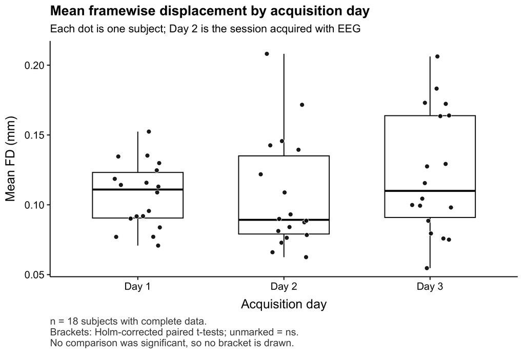

```r
p_mean_day <- qc_panel(
  mean_day,
  y_lab    = "Mean FD (mm)",
  x_title  = "Acquisition day",
  title    = "Mean framewise displacement by acquisition day",
  subtitle = "Each dot is one subject; Day 2 is the session acquired with EEG",
  caption  = brk_caption(n_distinct(mean_day$ID), f_mean_day$t_ph),
  pw       = f_mean_day$t_ph
)

p_mean_day
```

```r
fd_pct(mean_day)
```

| grp | mean | change vs first (%) |
| --- | --- | --- |
| Day 1 | 0.1070 | 0.00 |
| Day 2 | 0.1066 | -0.35 |
| Day 3 | 0.1228 | 14.77 |

Log check, since a proportional change is the more natural model for a positive quantity:

```r
get_anova_table(f_mean_day$aov_log, correction = "auto")
```

|  | Effect | DFn | DFd | F | p | p<.05 | ges |
| --- | --- | --- | --- | --- | --- | --- | --- |
| 1 | grp | 2 | 34 | 2.959 | 0.065 |  | 0.033 |

## Max FD

```r
fd_summary(max_day)
```

| grp | n | mean | sd | median | IQR | min | max |
| --- | --- | --- | --- | --- | --- | --- | --- |
| Day 1 | 18 | 0.5128 | 0.3193 | 0.3870 | 0.5232 | 0.1686 | 1.1147 |
| Day 2 | 18 | 0.5873 | 0.6387 | 0.3802 | 0.2620 | 0.1958 | 2.8009 |
| Day 3 | 18 | 0.9582 | 1.2561 | 0.4713 | 0.7418 | 0.1590 | 5.3971 |

```r
f_max_day <- fd_fit(max_day)
```

```r
get_anova_table(f_max_day$aov, correction = "auto")
```

|  | Effect | DFn | DFd | F | p | p<.05 | ges |
| --- | --- | --- | --- | --- | --- | --- | --- |
| 1 | grp | 1.24 | 21 | 1.451 | 0.249 |  | 0.055 |

```r
f_max_day$aov$`Mauchly's Test for Sphericity`
```

|  | Effect | W | p | p<.05 |
| --- | --- | --- | --- | --- |
| 1 | grp | 0.381 | 0.000443 | * |

```r
f_max_day$shapiro
```

| comparison | W | p |
| --- | --- | --- |
| Day 2 - Day 1 | 0.7360149 | 2.161922e-04 |
| Day 3 - Day 1 | 0.6195571 | 1.064285e-05 |

```r
f_max_day$friedman
```

|  | .y. | n | statistic | df | p | method |
| --- | --- | --- | --- | --- | --- | --- |
| 1 | y | 18 | 2.111111 | 2 | 0.347999 | Friedman test |

```r
f_max_day$kendall
```

|  | .y. | n | effsize | method | magnitude |
| --- | --- | --- | --- | --- | --- |
| 1 | y | 18 | 0.05864198 | Kendall W | small |

```r
f_max_day$t_ph |> select(group1, group2, statistic, df, p, p.adj, p.adj.signif)
```

| group1 | group2 | statistic | df | p | p.adj | p.adj.signif |
| --- | --- | --- | --- | --- | --- | --- |
| Day 1 | Day 2 | -0.5403836 | 17 | 0.596 | 0.608 | ns |
| Day 1 | Day 3 | -1.4536260 | 17 | 0.164 | 0.492 | ns |
| Day 2 | Day 3 | -1.0597228 | 17 | 0.304 | 0.608 | ns |

```r
f_max_day$w_ph |> select(group1, group2, statistic, p, p.adj, p.adj.signif)
```

| group1 | group2 | statistic | p | p.adj | p.adj.signif |
| --- | --- | --- | --- | --- | --- |
| Day 1 | Day 2 | 91 | 0.832 | 0.912 | ns |
| Day 1 | Day 3 | 61 | 0.304 | 0.912 | ns |
| Day 2 | Day 3 | 62 | 0.325 | 0.912 | ns |

The y axis is logarithmic here: max FD spans more than an order of magnitude across subjects (0.16 to 5.4 mm), and on a linear axis a single 5 mm outlier compresses every box into the bottom fifth of the panel. The boxes and points are the same data as everywhere else in this report, only the scale differs.

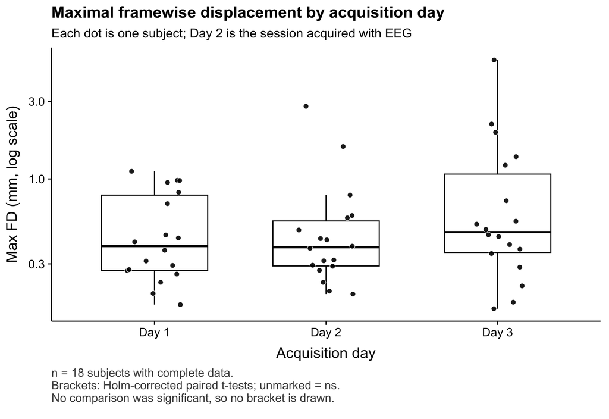

```r
p_max_day <- qc_panel(
  max_day,
  y_lab    = "Max FD (mm, log scale)",
  x_title  = "Acquisition day",
  title    = "Maximal framewise displacement by acquisition day",
  subtitle = "Each dot is one subject; Day 2 is the session acquired with EEG",
  caption  = brk_caption(n_distinct(max_day$ID), f_max_day$t_ph),
  pw       = f_max_day$t_ph,
  log_y    = TRUE
)

p_max_day
```

```r
fd_pct(max_day)
```

| grp | mean | change vs first (%) |
| --- | --- | --- |
| Day 1 | 0.5128 | 0.00 |
| Day 2 | 0.5873 | 14.52 |
| Day 3 | 0.9582 | 86.86 |

```r
get_anova_table(f_max_day$aov_log, correction = "auto")
```

|  | Effect | DFn | DFd | F | p | p<.05 | ges |
| --- | --- | --- | --- | --- | --- | --- | --- |
| 1 | grp | 1.38 | 23.42 | 1.182 | 0.307 |  | 0.037 |

# Part 2: within Day 2 (runs 2-5)

```r
mean_d2 <- prep_fd(fd, "mean_FD", d2_runs, d2_labels)
max_d2  <- prep_fd(fd, "max_FD",  d2_runs, d2_labels)

cat("Complete cases: ", n_distinct(mean_d2$ID), " of ",
    attr(mean_d2, "n_all"), " subjects with any Day 2 run\n", sep = "")
```

```
## Complete cases: 21 of 22 subjects with any Day 2 run
```

```r
fd |>
  filter(run %in% d2_runs) |>
  group_by(ID) |>
  filter(dplyr::n() < length(d2_runs)) |>
  summarise(runs_present = paste(sort(unique(run)), collapse = ", "), .groups = "drop")
```

| ID | runs_present |
| --- | --- |
| sub-31 | 2, 3, 4 |

## Mean FD

```r
fd_summary(mean_d2)
```

| grp | n | mean | sd | median | IQR | min | max |
| --- | --- | --- | --- | --- | --- | --- | --- |
| Rest 2 | 21 | 0.1019 | 0.0363 | 0.0899 | 0.0435 | 0.0528 | 0.2081 |
| Rest 3 | 21 | 0.1062 | 0.0373 | 0.0984 | 0.0457 | 0.0677 | 0.2212 |
| Rest 4 | 21 | 0.0986 | 0.0326 | 0.0907 | 0.0473 | 0.0599 | 0.1968 |
| Rest 5 | 21 | 0.0921 | 0.0240 | 0.0886 | 0.0224 | 0.0580 | 0.1644 |

```r
f_mean_d2 <- fd_fit(mean_d2)
```

```r
get_anova_table(f_mean_d2$aov, correction = "auto")
```

|  | Effect | DFn | DFd | F | p | p<.05 | ges |
| --- | --- | --- | --- | --- | --- | --- | --- |
| 1 | grp | 1.78 | 35.64 | 2.186 | 0.132 |  | 0.025 |

```r
f_mean_d2$aov$`Mauchly's Test for Sphericity`
```

|  | Effect | W | p | p<.05 |
| --- | --- | --- | --- | --- |
| 1 | grp | 0.264 | 0.000147 | * |

```r
f_mean_d2$shapiro
```

| comparison | W | p |
| --- | --- | --- |
| Rest 3 - Rest 2 | 0.9561020 | 0.4413438 |
| Rest 4 - Rest 2 | 0.9267351 | 0.1183872 |
| Rest 5 - Rest 2 | 0.9457160 | 0.2820085 |

```r
f_mean_d2$friedman
```

|  | .y. | n | statistic | df | p | method |
| --- | --- | --- | --- | --- | --- | --- |
| 1 | y | 21 | 7.114286 | 3 | 0.06834295 | Friedman test |

```r
f_mean_d2$kendall
```

|  | .y. | n | effsize | method | magnitude |
| --- | --- | --- | --- | --- | --- |
| 1 | y | 21 | 0.1129252 | Kendall W | small |

```r
f_mean_d2$t_ph |> select(group1, group2, statistic, df, p, p.adj, p.adj.signif)
```

| group1 | group2 | statistic | df | p | p.adj | p.adj.signif |
| --- | --- | --- | --- | --- | --- | --- |
| Rest 2 | Rest 3 | -0.5410023 | 20 | 0.594 | 1.000 | ns |
| Rest 2 | Rest 4 | 0.5083895 | 20 | 0.617 | 1.000 | ns |
| Rest 2 | Rest 5 | 1.7108286 | 20 | 0.103 | 0.309 | ns |
| Rest 3 | Rest 4 | 2.0374155 | 20 | 0.055 | 0.276 | ns |
| Rest 3 | Rest 5 | 2.5565133 | 20 | 0.019 | 0.113 | ns |
| Rest 4 | Rest 5 | 2.0076777 | 20 | 0.058 | 0.276 | ns |

```r
f_mean_d2$w_ph |> select(group1, group2, statistic, p, p.adj, p.adj.signif)
```

| group1 | group2 | statistic | p | p.adj | p.adj.signif |
| --- | --- | --- | --- | --- | --- |
| Rest 2 | Rest 3 | 104 | 0.708 | 0.786 | ns |
| Rest 2 | Rest 4 | 141 | 0.393 | 0.786 | ns |
| Rest 2 | Rest 5 | 159 | 0.137 | 0.411 | ns |
| Rest 3 | Rest 4 | 171 | 0.055 | 0.273 | ns |
| Rest 3 | Rest 5 | 176 | 0.035 | 0.211 | ns |
| Rest 4 | Rest 5 | 166 | 0.082 | 0.329 | ns |

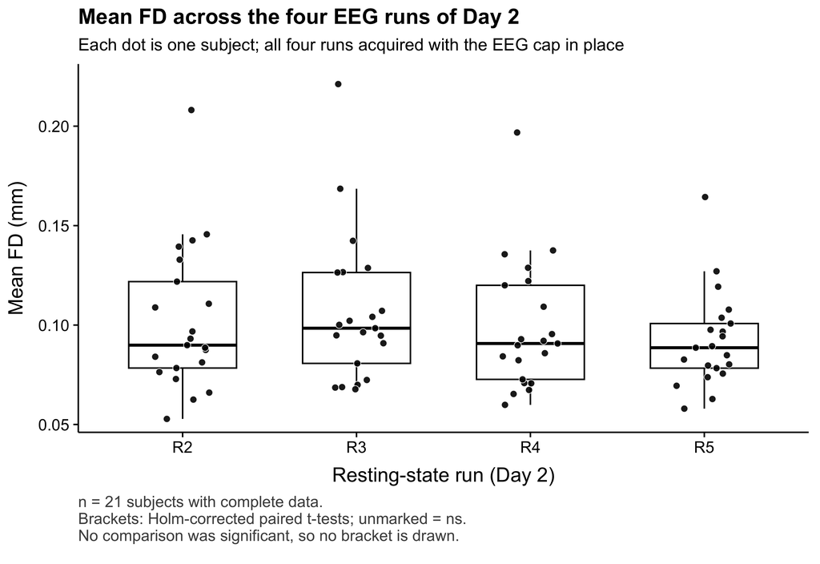

```r
p_mean_d2 <- qc_panel(
  mean_d2,
  y_lab    = "Mean FD (mm)",
  x_title  = "Resting-state run (Day 2)",
  title    = "Mean FD across the four EEG runs of Day 2",
  subtitle = "Each dot is one subject; all four runs acquired with the EEG cap in place",
  caption  = brk_caption(n_distinct(mean_d2$ID), f_mean_d2$t_ph),
  pw       = f_mean_d2$t_ph,
  short    = \(s) sub("^Rest ", "R", s)
)

p_mean_d2
```

```r
fd_pct(mean_d2)
```

| grp | mean | change vs first (%) |
| --- | --- | --- |
| Rest 2 | 0.1019 | 0.00 |
| Rest 3 | 0.1062 | 4.22 |
| Rest 4 | 0.0986 | -3.27 |
| Rest 5 | 0.0921 | -9.60 |

```r
get_anova_table(f_mean_d2$aov_log, correction = "auto")
```

|  | Effect | DFn | DFd | F | p | p<.05 | ges |
| --- | --- | --- | --- | --- | --- | --- | --- |
| 1 | grp | 2.22 | 44.49 | 2.178 | 0.12 |  | 0.022 |

## Max FD

```r
fd_summary(max_d2)
```

| grp | n | mean | sd | median | IQR | min | max |
| --- | --- | --- | --- | --- | --- | --- | --- |
| Rest 2 | 21 | 0.6379 | 0.6430 | 0.3858 | 0.3963 | 0.1466 | 2.8009 |
| Rest 3 | 21 | 0.6328 | 0.4509 | 0.4430 | 0.5997 | 0.1941 | 1.8568 |
| Rest 4 | 21 | 0.6672 | 0.3983 | 0.5340 | 0.5018 | 0.1803 | 1.7589 |
| Rest 5 | 21 | 0.5327 | 0.3624 | 0.4125 | 0.3862 | 0.1344 | 1.4649 |

```r
f_max_d2 <- fd_fit(max_d2)
```

```r
get_anova_table(f_max_d2$aov, correction = "auto")
```

|  | Effect | DFn | DFd | F | p | p<.05 | ges |
| --- | --- | --- | --- | --- | --- | --- | --- |
| 1 | grp | 1.74 | 34.78 | 0.396 | 0.648 |  | 0.012 |

```r
f_max_d2$aov$`Mauchly's Test for Sphericity`
```

|  | Effect | W | p | p<.05 |
| --- | --- | --- | --- | --- |
| 1 | grp | 0.238 | 6.21e-05 | * |

```r
f_max_d2$shapiro
```

| comparison | W | p |
| --- | --- | --- |
| Rest 3 - Rest 2 | 0.8981211 | 0.03218294 |
| Rest 4 - Rest 2 | 0.8713488 | 0.01013444 |
| Rest 5 - Rest 2 | 0.9054249 | 0.04463650 |

```r
f_max_d2$friedman
```

|  | .y. | n | statistic | df | p | method |
| --- | --- | --- | --- | --- | --- | --- |
| 1 | y | 21 | 3.514286 | 3 | 0.318914 | Friedman test |

```r
f_max_d2$kendall
```

|  | .y. | n | effsize | method | magnitude |
| --- | --- | --- | --- | --- | --- |
| 1 | y | 21 | 0.05578231 | Kendall W | small |

```r
f_max_d2$t_ph |> select(group1, group2, statistic, df, p, p.adj, p.adj.signif)
```

| group1 | group2 | statistic | df | p | p.adj | p.adj.signif |
| --- | --- | --- | --- | --- | --- | --- |
| Rest 2 | Rest 3 | 0.03003433 | 20 | 0.976 | 1.000 | ns |
| Rest 2 | Rest 4 | -0.17711785 | 20 | 0.861 | 1.000 | ns |
| Rest 2 | Rest 5 | 0.64448965 | 20 | 0.527 | 1.000 | ns |
| Rest 3 | Rest 4 | -0.51706885 | 20 | 0.611 | 1.000 | ns |
| Rest 3 | Rest 5 | 0.93006056 | 20 | 0.363 | 1.000 | ns |
| Rest 4 | Rest 5 | 1.75739330 | 20 | 0.094 | 0.565 | ns |

```r
f_max_d2$w_ph |> select(group1, group2, statistic, p, p.adj, p.adj.signif)
```

| group1 | group2 | statistic | p | p.adj | p.adj.signif |
| --- | --- | --- | --- | --- | --- |
| Rest 2 | Rest 3 | 91 | 0.412 | 1.000 | ns |
| Rest 2 | Rest 4 | 90 | 0.393 | 1.000 | ns |
| Rest 2 | Rest 5 | 122 | 0.838 | 1.000 | ns |
| Rest 3 | Rest 4 | 104 | 0.708 | 1.000 | ns |
| Rest 3 | Rest 5 | 157 | 0.157 | 0.785 | ns |
| Rest 4 | Rest 5 | 163 | 0.103 | 0.618 | ns |

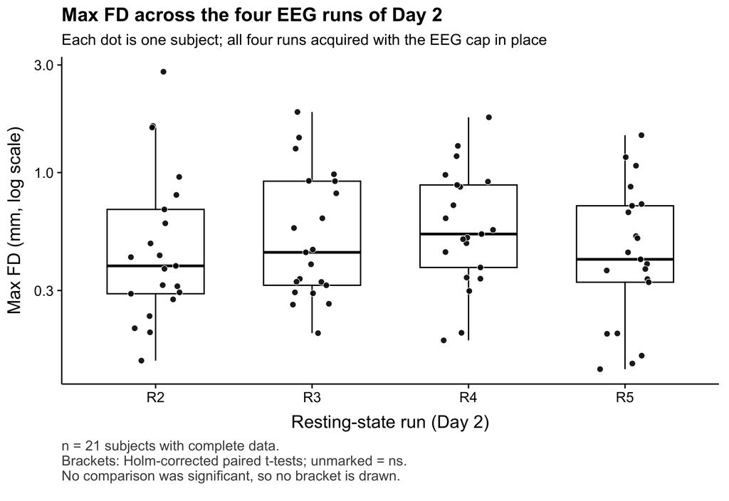

```r
p_max_d2 <- qc_panel(
  max_d2,
  y_lab    = "Max FD (mm, log scale)",
  x_title  = "Resting-state run (Day 2)",
  title    = "Max FD across the four EEG runs of Day 2",
  subtitle = "Each dot is one subject; all four runs acquired with the EEG cap in place",
  caption  = brk_caption(n_distinct(max_d2$ID), f_max_d2$t_ph),
  pw       = f_max_d2$t_ph,
  log_y    = TRUE,
  short    = \(s) sub("^Rest ", "R", s)
)

p_max_d2
```

```r
fd_pct(max_d2)
```

| grp | mean | change vs first (%) |
| --- | --- | --- |
| Rest 2 | 0.6379 | 0.00 |
| Rest 3 | 0.6328 | -0.79 |
| Rest 4 | 0.6672 | 4.60 |
| Rest 5 | 0.5327 | -16.49 |

```r
get_anova_table(f_max_d2$aov_log, correction = "auto")
```

|  | Effect | DFn | DFd | F | p | p<.05 | ges |
| --- | --- | --- | --- | --- | --- | --- | --- |
| 1 | grp | 2.16 | 43.29 | 0.985 | 0.387 |  | 0.025 |

# Summary of observed effects

**Head motion does not differ between the three acquisition days.** Mean FD is 0.107 mm (Day 1), 0.107 mm (Day 2) and 0.123 mm (Day 3). The ANOVA is nominally significant (*F*(2, 34) = 3.82, *p* = 0.032, ges = 0.042), but that result does not hold up: no post-hoc comparison survives Holm correction (smallest *p*<sub>adj</sub> = 0.065), Friedman’s test on the same data gives *p* = 0.211 with Kendall’s *W* = 0.086 (small), and the effect drops to *p* = 0.065 on the log scale. The nominal effect is carried by Day 3 being about 15% higher than Day 1, not by the EEG day. Max FD shows nothing at all (*F*(1.24, 21) = 1.45, *p* = 0.249; Friedman *p* = 0.348).

**In total, 0 of 36 post-hoc comparisons in this report survive Holm correction**, which is why none of the four figures carries a significance bracket.

# Does motion explain the Day 2 tSNR loss?

This section is not part of the tSNR analysis being replicated; it is here because the FD result bears directly on how the tSNR result should be read. The tSNR report found a ~6% drop in grey-matter tSNR on Day 2, uniform across echoes. Motion is the obvious alternative explanation — a subject who moves more with a cap on would show lower tSNR for reasons having nothing to do with the cap’s effect on the signal.

The data above already argues against the simplest version of that: mean FD on Day 2 (0.107 mm) is essentially identical to Day 1 (0.107 mm), *p* = 0.956. A group-level tSNR drop cannot be produced by a group-level motion increase that did not happen. But that leaves a subtler possibility open: motion might still explain *which* subjects lost the most tSNR. Testing that needs the two tables joined.

```r
tsnr_wide <- read.csv("tSNR_results.txt", na.strings = c("NA", "NaN", ""))
names(tsnr_wide)[1] <- "ID"

# tSNR averaged over the four echoes, for runs 1 and 2.
tsnr_delta <- tsnr_wide |>
  transmute(
    ID     = ID,
    tsnr_1 = rowMeans(across(c(r1e1, r1e2, r1e3, r1e4))),
    tsnr_2 = rowMeans(across(c(r2e1, r2e2, r2e3, r2e4)))
  ) |>
  mutate(d_tsnr = tsnr_2 - tsnr_1)

fd_delta <- fd |>
  filter(run %in% c(1, 2)) |>
  select(ID, run, mean_FD) |>
  pivot_wider(names_from = run, values_from = mean_FD, names_prefix = "fd_") |>
  mutate(d_fd = fd_2 - fd_1)

joined <- inner_join(tsnr_delta, fd_delta, by = "ID") |>
  filter(!is.na(d_tsnr), !is.na(d_fd))

cat("Subjects with both measures on runs 1 and 2: ", nrow(joined), "\n", sep = "")
```

```
## Subjects with both measures on runs 1 and 2: 20
```

The change in motion and the change in tSNR *are* related across subjects:

```r
cor.test(joined$d_fd, joined$d_tsnr, method = "spearman")
```

```
##
##  Spearman's rank correlation rho
##
## data:  joined$d_fd and joined$d_tsnr
## S = 1874, p-value = 0.07453
## alternative hypothesis: true rho is not equal to 0
## sample estimates:
##        rho
## -0.4090226
```

So motion is not irrelevant. The question is whether it accounts for the *mean* drop or only for the spread around it. Regressing the tSNR change on the motion change separates the two: the slope is the motion contribution, and the intercept is the tSNR change expected for a subject whose motion did not change at all.

```r
fit_conf <- lm(d_tsnr ~ d_fd, data = joined)
summary(fit_conf)
```

```
##
## Call:
## lm(formula = d_tsnr ~ d_fd, data = joined)
##
## Residuals:
##     Min      1Q  Median      3Q     Max
## -7.2984 -2.1767 -0.7104  2.9830  7.5159
##
## Coefficients:
##             Estimate Std. Error t value Pr(>|t|)
## (Intercept)  -3.7301     0.9524  -3.917  0.00101 **
## d_fd        -74.0616    34.7941  -2.129  0.04736 *
## ---
## Signif. codes:  0 '***' 0.001 '**' 0.01 '*' 0.05 '.' 0.1 ' ' 1
##
## Residual standard error: 4.253 on 18 degrees of freedom
## Multiple R-squared:  0.2011, Adjusted R-squared:  0.1567
## F-statistic: 4.531 on 1 and 18 DF,  p-value: 0.04736
```

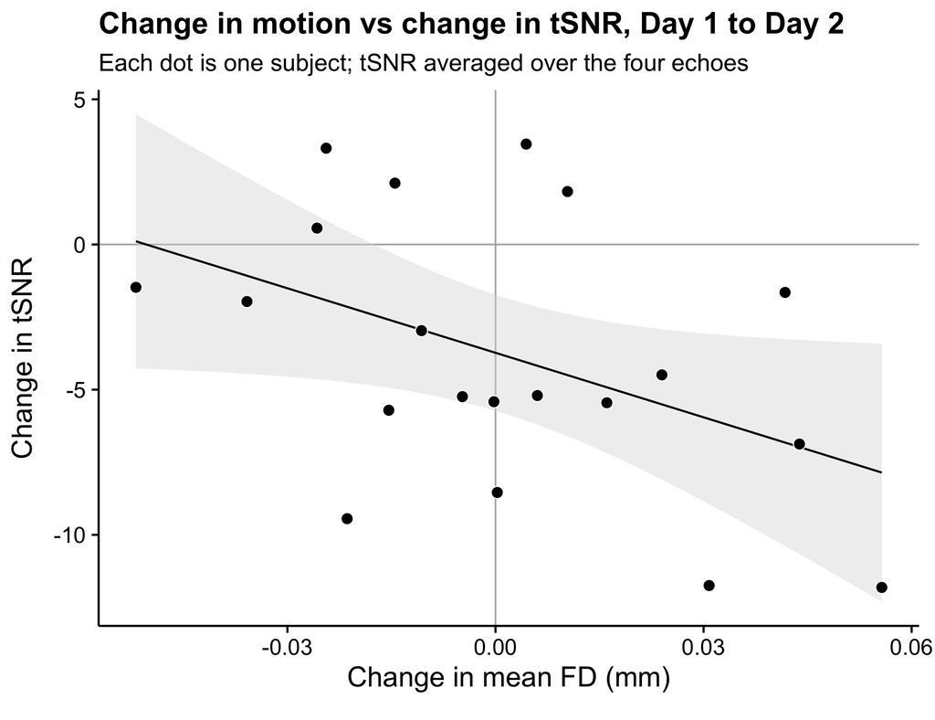

```r
ggplot(joined, aes(x = d_fd, y = d_tsnr)) +
  geom_hline(yintercept = 0, colour = "grey70", linewidth = 0.4) +
  geom_vline(xintercept = 0, colour = "grey70", linewidth = 0.4) +
  geom_smooth(method = "lm", formula = y ~ x, colour = "black",
              linewidth = 0.5, fill = "grey85") +
  geom_point(shape = 21, fill = "black", colour = "white", size = 2.6, stroke = 0.4) +
  labs(
    title    = "Change in motion vs change in tSNR, Day 1 to Day 2",
    subtitle = "Each dot is one subject; tSNR averaged over the four echoes",
    x        = "Change in mean FD (mm)",
    y        = "Change in tSNR"
  )
```

**Both things are true, and they answer different questions.** Across the 20 subjects with both measures, motion change does predict tSNR change, in the expected direction and with a respectable effect size: Spearman *rho* = -0.41 (*p* = 0.075), and in the regression the slope is significant (*b* = -74.1 tSNR units per mm of FD, *p* = 0.047, R² = 0.2). Subjects who moved more on Day 2 did lose more tSNR. Motion is a genuine contributor to the *subject-to-subject spread* in the Day 2 loss.

It is not, however, the cause of the loss itself. The regression intercept — the expected tSNR change for a subject whose motion was identical on the two days — is -3.73 (*p* = 0.0010), against a raw mean change of -3.84. In other words, essentially the entire mean drop remains at zero motion change. That is the expected result given the group-level numbers: only 10 of 20 subjects moved more on Day 2 at all, and mean FD across the group was flat, so motion has no mean shift available to transmit to tSNR.

The reading in the tSNR report therefore stands, with one refinement. The Day 2 tSNR loss is a property of the EEG hardware being in the bore rather than of subjects behaving differently while wearing it — but motion still modulates how large that loss is for a given subject, and a study using per-subject Day 2 tSNR as a covariate would do well to include mean FD alongside it. Two caveats on this section specifically: n = 20 is small for a correlation, so the slope estimate is imprecise; and FD and tSNR are not independent measurements, since motion enters the tSNR denominator directly through the temporal standard deviation.